# qPCR analysis

Daniel Hammarström

27 10 2021

## Packages

To import and analyze qPCR data using R, you will need the packages `qpcR`, `parallel` and `qpcrpal`. Installing `qpcrpal` with vignettes will take some time. Set `build_vignettes` to `FALSE` if you are in a hurry.

```r
# Check if qpcR, readxl and parallel are installed, otherwise install
if("qpcR" %in% rownames(installed.packages()) == FALSE) install.packages("qpcR")
if("readxl" %in% rownames(installed.packages()) == FALSE) install.packages("readxl")
if("parallel" %in% rownames(installed.packages()) == FALSE) install.packages("parallel")

# Check if qpcrpal is installed, otherwise install
if("qpcrpal" %in% rownames(installed.packages()) == FALSE) {

  library(remotes)
  remotes::install_github("dhammarstrom/qpcrpal", build_vignettes = TRUE)

}

# Load packages
library(qpcR)
library(readxl)
library(parallel)
library(qpcrpal)
library(tidyverse)
```

## Exploring the data

- Reading and analyzing qPCR-data is done in a stepwise manner using `qpcrpal`.
- The `read_quant5` function organizes the data from the instrument (QuantStudio 5)
- `model_qpcr` creates models of the fluorecense from each reaction
- `analyze_models` use the information in each model to calculate summaries for each reaction.

```r
group1 <- read_quant5("./data/qpcr/IDR4000-Group1-precision.xls", skip = 47) %>%
  mutate(ID = paste0(Well, "_", ID))


models <- model_qpcr(group1)


results_group1 <- analyze_models(models)
```

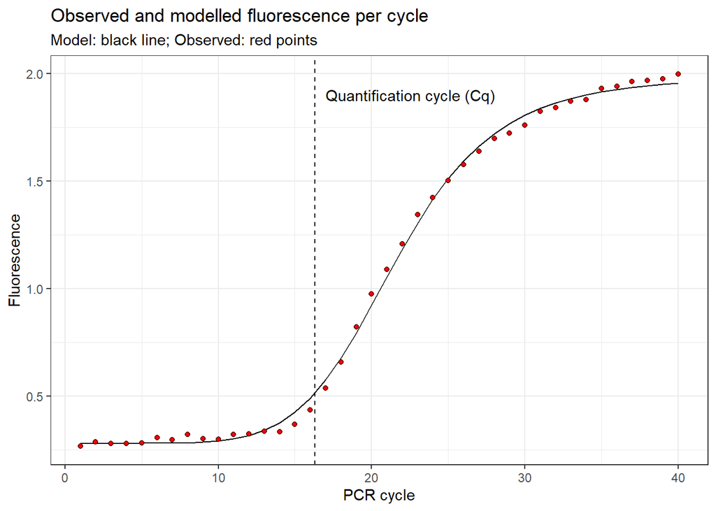

- `qpcrpal` organize the data and uses functions from the `qpcR` package to model the data.
- A quantification cycle can be calculated from each modelled reaction.
- The `analyze_models` function returs alot of values, the cpD2 can be used as the Cq value.

## Exercise: Calculate precision

- Clone the repository “dhammarstrom/IDR4000-2021” and read a cleaned data set of precision values
- Determine a set of rules (e.g. remove “bad” reactions, the smallest and biggest value, or everything below 10 and above 30)
- Determine the precision for each student as the coefficient of variation $CV = \frac{SD}{Mean}$
- Work in groups: **Who has the lowest CV??**

```r
precision <- readRDS("./data/rna-lab-cq-precision.RDS")
```

## Estimation of reaction efficiency

- In theory, a PCR reaction doubles the number of target copies each cycle.
- When plotting log10(concentrations) against Cq values we can estimate efficiency

$$Efficiency = 10^{-1/slope}$$
- When the slope is ~ -3.3

$$Efficiency = 10^{-1/-3.32} = 2$$
- This means that for each cycle we have a doubling of PCR product. A difference in 3.32 cycles would also indicate a 10-fold difference in cDNA concentrations

$$2^{3.32} = 10$$

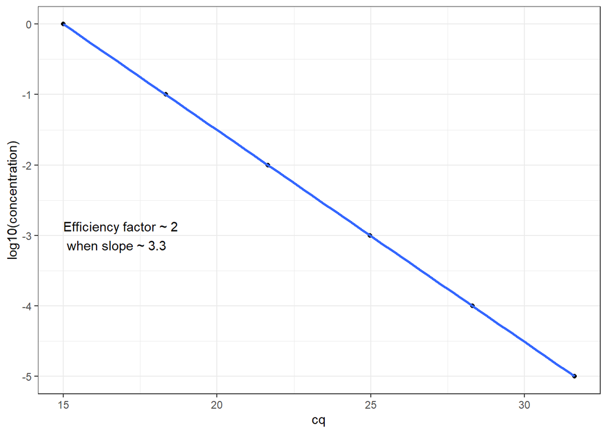

### Estimation of primer efficiency using real data: Exercises

- Use the data stored in `./data/efficiency-estimate-data.RDS` to plot Cq-values against log10 concentrations. Try to replicate the figure below.
- Create a model (`lm(cq ~ log10(concentration), data = dat`) for each target primer and extract the slope.
- Use the slope to calculate the efficiency factor (`= 10^-(1/slope)`).
- Look at the plot, what is the effect of removing measurements that are clear outliers? Use `filter` to remove specific cq-values from each primer and re-do the calculations.

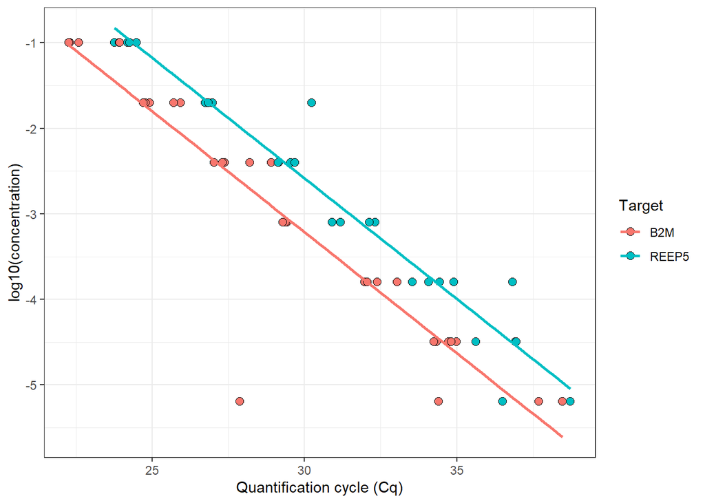

Efficiency calculations made from serial dilution of cDNA

## Estimate fold-change

- Use `./data/foldchange-data.RDS` transform Cq-values to a linear scale using an efficiency factor of 2.
- Compute an average normalization reference of all reference genes per sample/timepoint.
- Calculate fold-change of target genes after normalization.